DS 6030 | Fall 2024 | University of Virginia

# Homework #6: SVM and Calibration

Author

Courtney Hodge

Published

October 17, 2024

# Required R packages and Directories

```r
dir_data= 'https://mdporter.github.io/teaching/data/' # data directory
library(tidyverse)  # functions for data manipulation
```

# COMPAS Recidivism Prediction

A recidivism risk model called COMPAS was the topic of a [ProPublica article](https://www.propublica.org/article/machine-bias-risk-assessments-in-criminal-sentencing/) on ML bias. Because the data and notebooks used for article was released on [github](https://github.com/propublica/compas-analysis), we can also evaluate the prediction bias (i.e., calibration).

This code will read in the *violent crime* risk score and apply the filtering used in the [analysis](https://github.com/propublica/compas-analysis/blob/master/Compas%20Analysis.ipynb).

```r
library(tidyverse)
df = read_csv("https://raw.githubusercontent.com/propublica/compas-analysis/master/compas-scores-two-years-violent.csv")

risk = df %>%
  filter(days_b_screening_arrest <= 30) %>%
  filter(days_b_screening_arrest >= -30) %>%
  filter(is_recid != -1) %>%
  filter(c_charge_degree != "O") %>%
  filter(v_score_text != 'N/A') %>%
  transmute(
    age, age_cat,
    charge = ifelse(c_charge_degree == "F", "Felony", "Misdemeanor"),
    race,
    sex,
    priors_count = priors_count...15,
    score = v_decile_score,              # the risk score {1,2,...,10}
    outcome = two_year_recid...53        # outcome {1 = two year recidivate}
  )
```

The `risk` data frame has the relevant information for completing the problems.

# Problem 1: COMPAS risk score

## a. Risk Score and Probability (table)

Assess the predictive bias in the COMPAS risk scores by evaluating the probability of recidivism, e.g. estimate $\Pr(Y = 1 \mid \text{Score}=x)$. Use any reasonable techniques (including Bayesian) to estimate the probability of recidivism for each risk score.

Specifically, create a table (e.g., data frame) that provides the following information:

- The COMPASS risk score.
- The point estimate of the probability of recidivism for each risk score.
- 95% confidence or credible intervals for the probability (e.g., Using normal theory, bootstrap, or Bayesian techniques).

Indicate the choices you made in estimation (e.g., state the prior if you used Bayesian methods).

**Solution**

```r
risk <- as.data.frame(risk)
```

```r
library(dplyr)

#group by score and calculate probabilities of recidivism
recidivism_summary <- risk |>
  group_by(score) |>
  summarise(
    Total = n(),
    Recidivated = sum(outcome),
    Probability = Recidivated / Total
  )

print(recidivism_summary)
```

```
# A tibble: 10 × 4
  score Total Recidivated Probability
  <dbl> <int>       <dbl>       <dbl>
1     1  1340          83      0.0619
2     2   622          58      0.0932
3     3   543          93      0.171
4     4   408          72      0.176
5     5   325          60      0.185
6     6   300          85      0.283
# ℹ 4 more rows
```

```r
# Add 95% confidence intervals using normal approximation
recidivism_summary <- recidivism_summary %>%
  mutate(
    SE = sqrt((Probability * (1 - Probability)) / Total),  # Standard error
    Lower_CI = Probability - 1.96 * SE,
    Upper_CI = Probability + 1.96 * SE
  )

# Ensure confidence intervals are within [0, 1] range
recidivism_summary$Lower_CI <- pmax(0, recidivism_summary$Lower_CI)
recidivism_summary$Upper_CI <- pmin(1, recidivism_summary$Upper_CI)

# View the updated table with confidence intervals
print(recidivism_summary)
```

```
# A tibble: 10 × 7
  score Total Recidivated Probability      SE Lower_CI Upper_CI
  <dbl> <int>       <dbl>       <dbl>   <dbl>    <dbl>    <dbl>
1     1  1340          83      0.0619 0.00658   0.0490   0.0748
2     2   622          58      0.0932 0.0117    0.0704   0.116
3     3   543          93      0.171  0.0162    0.140    0.203
4     4   408          72      0.176  0.0189    0.139    0.213
5     5   325          60      0.185  0.0215    0.142    0.227
6     6   300          85      0.283  0.0260    0.232    0.334
# ℹ 4 more rows
```

## b. Risk Score and Probability (plot)

Make a plot of the risk scores and corresponding estimated probability of recidivism.

- Put the risk score on the x-axis and estimate probability of recidivism on y-axis.
- Add the 95% confidence or credible intervals calculated in part a.
- Comment on the patterns you see.

**Solution**

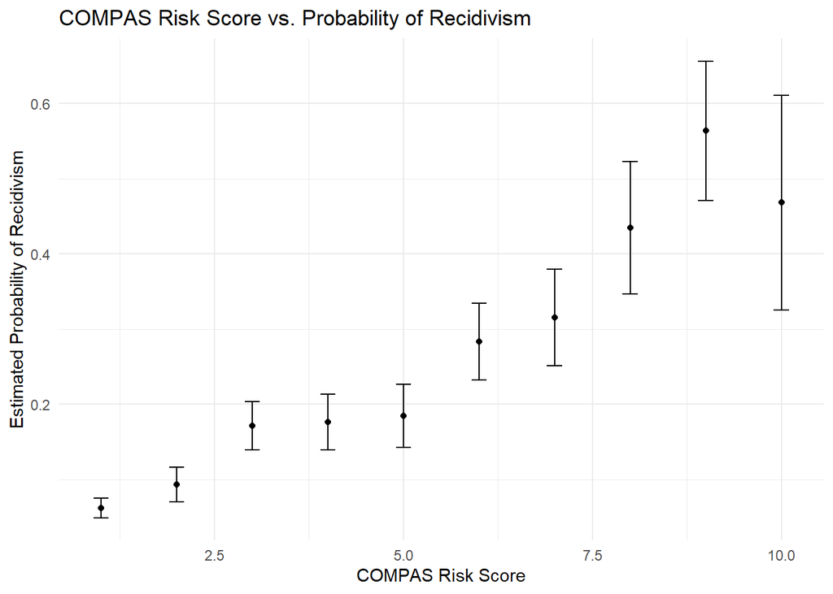

```r
library(ggplot2)

ggplot(recidivism_summary, aes(x = score, y = Probability)) +
  geom_point() +
  geom_errorbar(aes(ymin = Lower_CI, ymax = Upper_CI), width = 0.2) +  # Add error bars for confidence intervals
  labs(
    title = "COMPAS Risk Score vs. Probability of Recidivism",
    x = "COMPAS Risk Score",
    y = "Estimated Probability of Recidivism"
  ) +
  theme_minimal()
```

> Based on the patterns above, we can see a general trend where the higher COMPAS risk scores have higher probabilities of recidivism.

> We also see the widths of the confidence intervals reflect the uncertainty in the estiamtes. For risk scores with fever observations, the intervals will be wider, meaning that there’s mroe uncertainty in those estimates.

## c. Risk Score and Probability (by race)

Repeat the analysis, but this time do so for every race. Produce a set of plots (one per race) and comment on the patterns.

**Solution**

```r
# Group by both race and score, then calculate probability and confidence intervals
recidivism_by_race <- risk %>%
  group_by(race, score) %>%
  summarise(
    Total = n(),
    Recidivated = sum(outcome),
    Probability = Recidivated / Total,
    SE = sqrt((Probability * (1 - Probability)) / Total),  # Standard error
    Lower_CI = Probability - 1.96 * SE,
    Upper_CI = Probability + 1.96 * SE
  ) %>%
  # Ensure confidence intervals are within [0, 1]
  mutate(
    Lower_CI = pmax(0, Lower_CI),
    Upper_CI = pmin(1, Upper_CI)
  )
# View the grouped data
print(recidivism_by_race)
```

```
# A tibble: 52 × 8
# Groups:   race [6]
  race             score Total Recidivated Probability     SE Lower_CI Upper_CI
  <chr>            <dbl> <int>       <dbl>       <dbl>  <dbl>    <dbl>    <dbl>
1 African-American     1   395          31      0.0785 0.0135   0.0520    0.105
2 African-American     2   294          28      0.0952 0.0171   0.0617    0.129
3 African-American     3   278          55      0.198  0.0239   0.151     0.245
4 African-American     4   233          40      0.172  0.0247   0.123     0.220
5 African-American     5   185          42      0.227  0.0308   0.167     0.287
6 African-American     6   191          59      0.309  0.0334   0.243     0.374
# ℹ 46 more rows
```

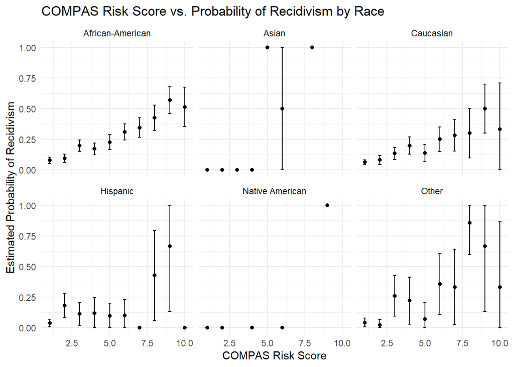

```r
# Plot with ggplot
ggplot(recidivism_by_race, aes(x = score, y = Probability)) +
  geom_point() +  # Plot points for each race and score
  geom_errorbar(aes(ymin = Lower_CI, ymax = Upper_CI), width = 0.2) +  # Add error bars
  facet_wrap(~race) +  # Create a separate plot for each race
  labs(
    title = "COMPAS Risk Score vs. Probability of Recidivism by Race",
    x = "COMPAS Risk Score",
    y = "Estimated Probability of Recidivism"
  ) +
  theme_minimal()  # Clean theme
```

## d. ROC Curves

Use the raw COMPAS risk scores to make a ROC curve for each race.

- Are the best discriminating models the ones you expected?
- Are the ROC curves helpful in evaluating the COMPAS risk score?

**Solution**

```r
library(pROC)
#group data by race and calculate ROC for each race

roc_curves <- risk |>
  group_by(race) |>
  summarise(
    roc = list(roc(outcome, score))
  )
```

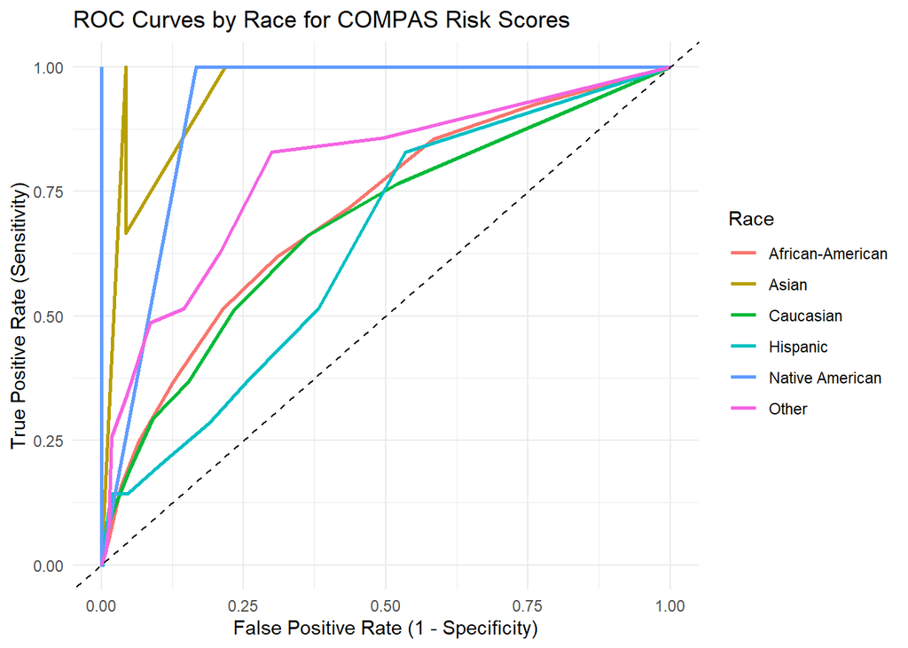

```r
# Extract the ROC curve data directly
roc_data <- roc_curves %>%
  rowwise() %>%
  mutate(
    # Extract the true positive rate (TPR) and false positive rate (FPR)
    tpr = list(roc$sensitivities),
    fpr = list(1 - roc$specificities)
  ) %>%
  unnest(c(tpr, fpr))  # Unnest to get long format data for plotting

# Now plot the ROC curves for each race
ggplot(roc_data, aes(x = fpr, y = tpr, color = race)) +
  geom_line(size = 1) +
  geom_abline(linetype = "dashed") +  # Add diagonal line (random classifier)
  labs(
    title = "ROC Curves by Race for COMPAS Risk Scores",
    x = "False Positive Rate (1 - Specificity)",
    y = "True Positive Rate (Sensitivity)"
  ) +
  theme_minimal() +
  scale_color_discrete(name = "Race")
```

```r
# Add AUC values for each race
roc_curves <- roc_curves %>%
  mutate(AUC = sapply(roc, auc))

# Print the AUC values for each race
print(roc_curves)
```

```
# A tibble: 6 × 3
  race             roc      AUC
  <chr>            <list> <dbl>
1 African-American <roc>  0.708
2 Asian            <roc>  0.978
3 Caucasian        <roc>  0.683
4 Hispanic         <roc>  0.641
5 Native American  <roc>  1
6 Other            <roc>  0.792
```

> The ROC curves are helpful in evaluating the compass risk score, but there are some hiccups that make it harder to read the data. With the five races and the others category, it looks kind of cluttered on the ROC curves by race for Compass risk scores graph, but we can see the general trends of the discriminating models clearly.

# Problem 2: Support Vector Machines (SVM)

Focus on Problem 1, we won’t have an SVM problem this week.